# Introduction to Time Series Analysis

ECON 707/807: Econometrics II

Rex Sitti

Old Dominion University - Strome College of Business

## Time Series

Sequential measurements or values of a single entity over time.

Why study time series data?

- Gross Domestic Product
- Unemployment
- Vehicle Demand
- Energy Consumption

## Forecasting

“Predict” outcomes of a time series in future (unobserved) periods.

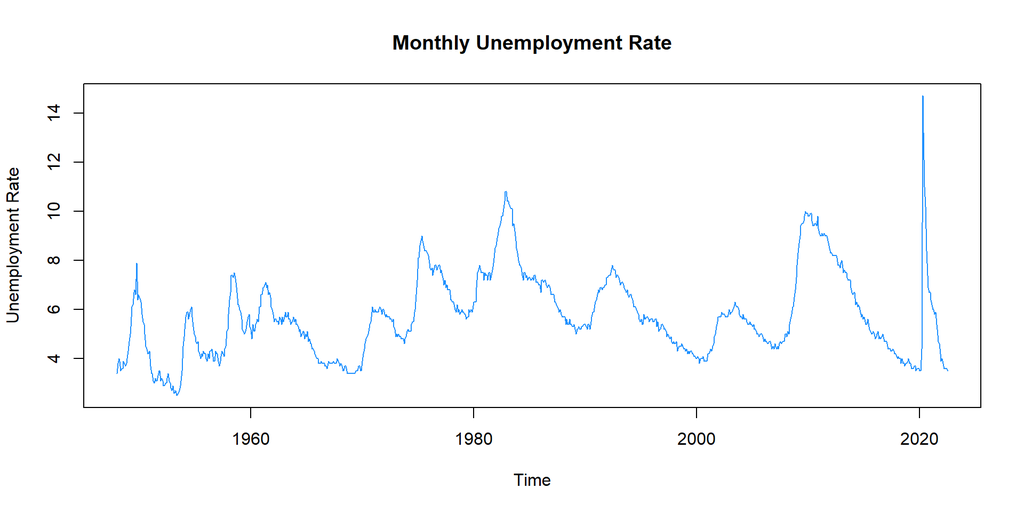

## Time Series Models

$$Y_{t} = f(Y_{t-1}, X_{t}, X_{t-1}, \tau_t, C_t, S_t)$$
where:

- $Y_{t-1}$ is a lagged value of $Y$
- $X_t$ is a contemporaneous independent value
- $X_{t-1}$ is a lagged value of $X$
- $\tau$ is the trend
- $C$ is the cycle
- $S$ is the season

Note: this model only considers what is *inside* the model!

## Statistics Review

- mean
- variance
- standard error
- central limit theorem (CLT)
- p-value
- $Y_i = \alpha + \beta X_i + \epsilon_{i}$
- causality
- [spurious](https://www.tylervigen.com/spurious-correlations)

## Forecasting Steps

1. Define Problem

   What am I trying to solve?
2. Gather Data

   FRED, WRDS, Etc.
3. Exploratory Data Analysis (EDA)

   Plot, Plot, Plot
4. Choose & Fit a Model

   $Y_{t} = f(Y_{t-1}, X_{t}, X_{t-1}, \tau_t, C_t, S_t)$
5. Evaluate, Forecast

## Packages and Functions

- `table()`
- `aggregate()`
- `match()`
- `paste()`, `paste0()`, `substr()`, `grepl()`, `gsub()`, `regexpr()`, `strsplit()`, `unlist()`

I have some materials [here](https://alexcardazzi.github.io/using-r/).

## Packages and Functions

- `for()`
- `if()`, `else`
- `ifelse()`
- `fixest`
- `scales::alpha()`
- `data.table::fread()`
- `readRDS()`, `saveRDS()`

## Packages and Functions

- `lubridate`<sup>1</sup>
- `tsibble`
- `forecast`
- `ts()`<sup>2</sup>
- `duplicated()`
[^1]: [lubridate](https://evoldyn.gitlab.io/evomics-2018/ref-sheets/R_lubridate.pdf)
[^2]: [ts](https://www.statmethods.net/advstats/timeseries.html)

## Install and Load Packages

## Make a Time Series

```
        date urate_t
1 1948-01-01     3.4
2 1948-02-01     3.8
3 1948-03-01     4.0
4 1948-04-01     3.9
5 1948-05-01     3.5
6 1948-06-01     3.6
```

## Plot a Time Series

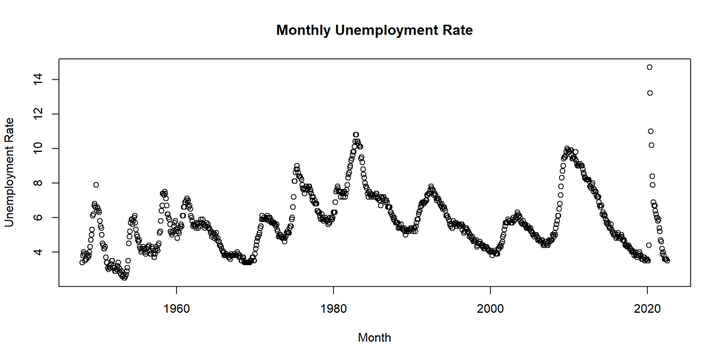

## Plot a Time Series

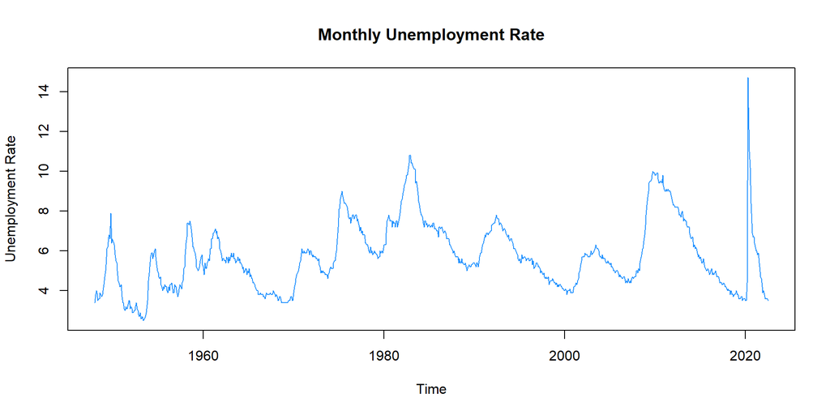

## Lags (Leads)

```
        date urate_t
1 1948-01-01     3.4
2 1948-02-01     3.8
3 1948-03-01     4.0
4 1948-04-01     3.9
5 1948-05-01     3.5
6 1948-06-01     3.6
```

```r
t <- 2:nrow(urate)
urate$urate_tm1 <- NA
urate$urate_tm1[t] <- urate$urate_t[t-1]
urate$urate_tp1 <- NA
urate$urate_tp1[t-1] <- urate$urate_t[t]
head(urate)
```

```
        date urate_t urate_tm1 urate_tp1
1 1948-01-01     3.4        NA       3.8
2 1948-02-01     3.8       3.4       4.0
3 1948-03-01     4.0       3.8       3.9
4 1948-04-01     3.9       4.0       3.5
5 1948-05-01     3.5       3.9       3.6
6 1948-06-01     3.6       3.5       3.6
```

## What about panels?

```
   state year        var
1     NY 2010 -0.6244301
2     NY 2011 -0.5803680
3     NY 2012 -0.8448485
11    VA 2010 -0.6242288
12    VA 2011 -0.4739917
13    VA 2012 -0.1084379
21    CA 2010 -0.1921306
22    CA 2011  0.2658745
23    CA 2012 -1.1671093
```

## What about panels?

```
   state year        var var_lag1
1     NY 2010 -0.6244301       NA
2     NY 2011 -0.5803680       NA
3     NY 2012 -0.8448485       NA
11    VA 2010 -0.6242288       NA
12    VA 2011 -0.4739917       NA
13    VA 2012 -0.1084379       NA
21    CA 2010 -0.1921306       NA
22    CA 2011  0.2658745       NA
23    CA 2012 -1.1671093       NA
```

Note: these data are already ordered.

## What about panels?

```
   state year        var   var_lag1
1     NY 2010 -0.6244301         NA
2     NY 2011 -0.5803680 -0.6244301
3     NY 2012 -0.8448485 -0.5803680
11    VA 2010 -0.6242288         NA
12    VA 2011 -0.4739917 -0.6242288
13    VA 2012 -0.1084379 -0.4739917
21    CA 2010 -0.1921306         NA
22    CA 2011  0.2658745 -0.1921306
23    CA 2012 -1.1671093  0.2658745
```

## Multiple Plots

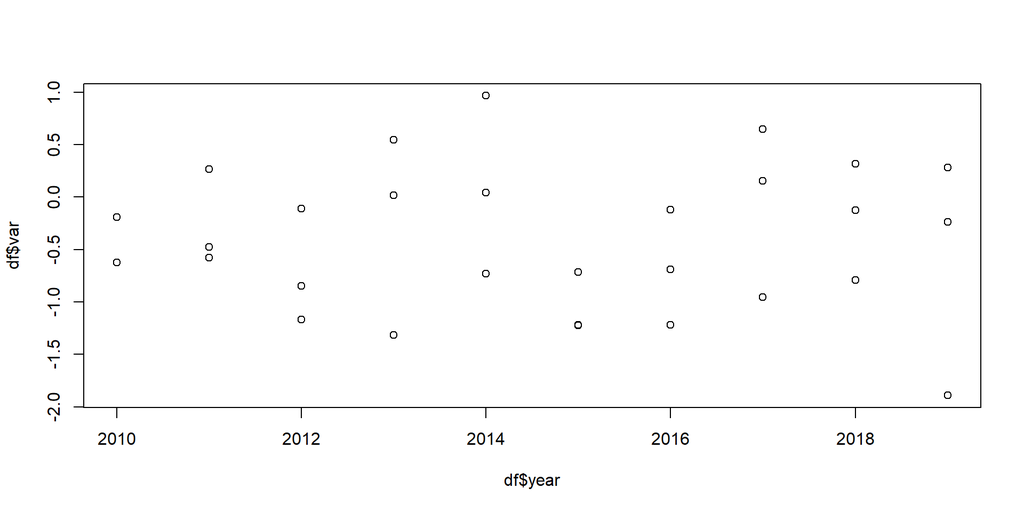

## Multiple Plots

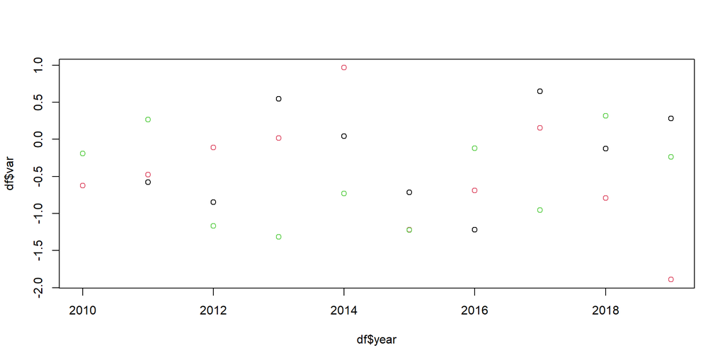

## Multiple Plots

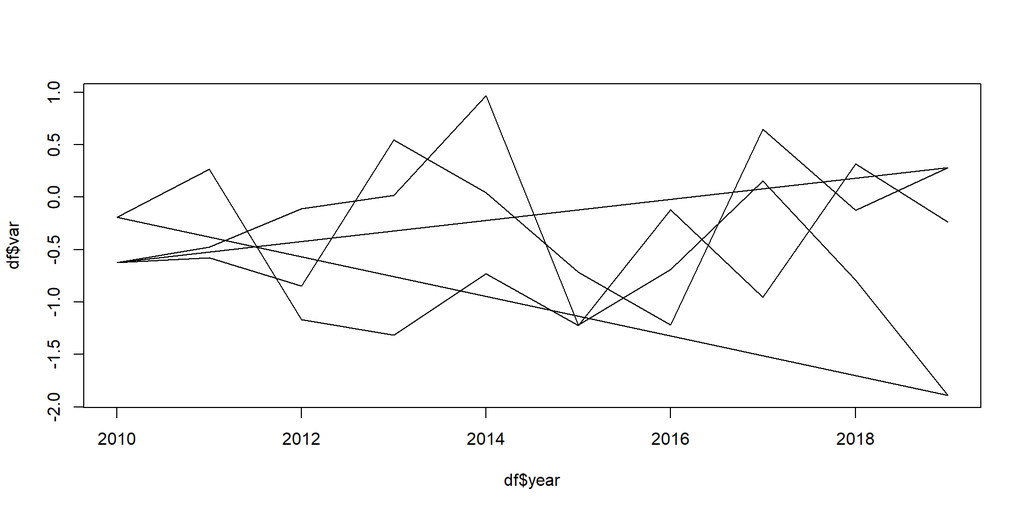

## Multiple Plots

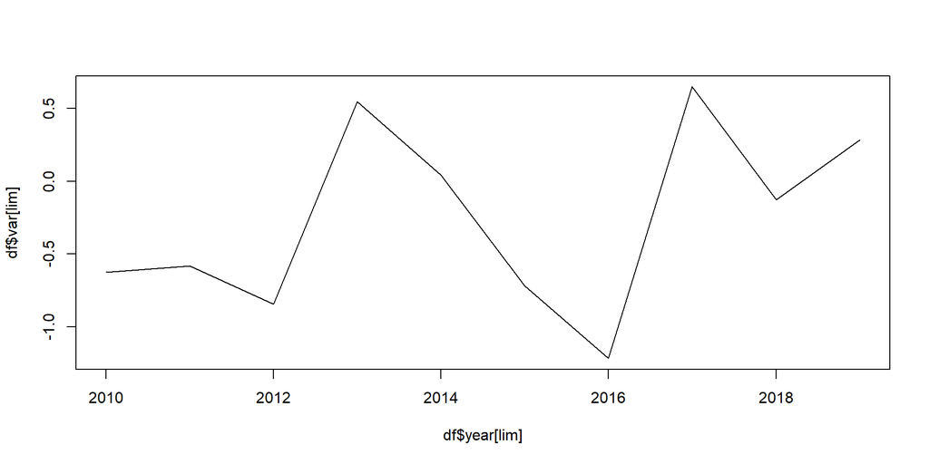

## Multiple Plots

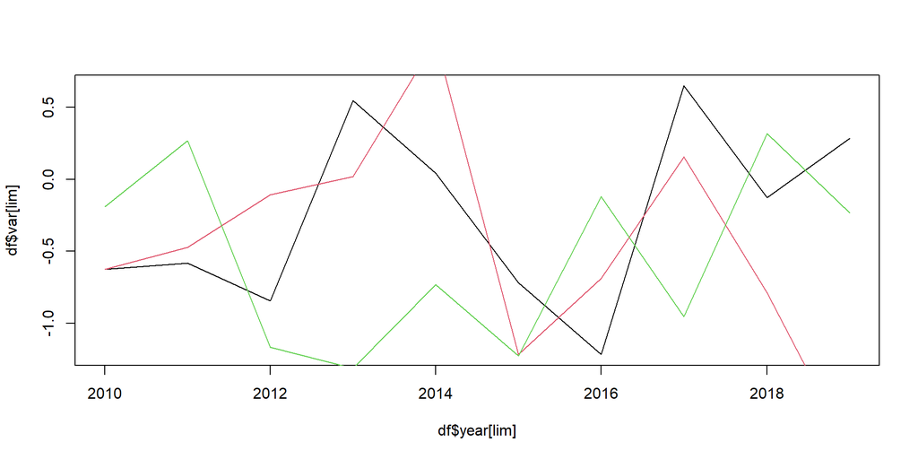

## Multiple Plots

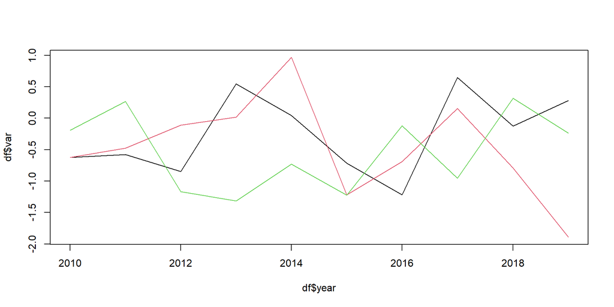

## Next Class

1. $E[y]$, $\hat{y}$
2. Loss Functions
3. Lags, Leads
4. Conditional Forecasts
5. Time Series Components

## Practice - Cleaning Data

1. Work on [#5](https://foresightbi.com.ng/microsoft-power-bi/dirty-data-samples-to-practice-on/#5_Jumbled_Customer_Details).
2. Work on [#8](https://foresightbi.com.ng/microsoft-power-bi/dirty-data-samples-to-practice-on/#8_Invoices_With_Merged_Categories_and_Merged_Amounts).

## Practice - Social Security

1. Navigate to the following link: here
2. Download the state-specific data.
3. Read in the data from Virginia.
   - Make some plots for a name of your choosing (time series, distributions, etc.)
4. Read in *all* of the data
   - Combine into one data.frame.
   - What state is your chosen name “most” popular?
   - What year is your chosen name “most” popular?
   - Analyze the “gender neutrality” of a relatively unisex name (e.g. “Alex”).
   - Analyze a common name and it’s nickname (e.g. “Alex” vs “Alexander”).